# Boston House Price Prediction

Notebook 2, continuation of Notebook 1. Using Random forest, Grid search.

Anurima Dey

28-April-2020

## Purpose of the project:

This notebook contains the non-regression models for the price prediction of Boston Housing. Do refer to notebook 1, for all the steps, and visualization of the data and corelation among various attibutes. We shall keep the basic steps same i.e. obtaining the data and the cleaning of data remains same.

Following that we shall proceed directly with the non regression models.

### Obtaining and cleaning the data.

The data is obtained from kaggle website.  
The displayed are the **features** of the dataset.

1. *CRIM* – per capita crime rate by town
2. *ZN* – proportion of residential land zoned for lots over 25,000 sq.ft
3. *INDUS* – proportion of non-retail business acres per town
4. *CHAS* – Charles River dummy variable (1 if tract bounds river; else 0)
5. *NOX* – nitric oxides concentration (parts per 10 million)
6. *RM* – average number of rooms per dwelling
7. *AGE* – proportion of owner-occupied units built prior to 1940
8. *DIS* – weighted distances to five Boston employment centres
9. *RAD* – index of accessibility to radial highways
10. *TAX* – full-value property-tax rate per $10,000
11. *PTRATIO* – pupil-teacher ratio by town
12. *B* – 1000(Bk - 0.63)^2 where Bk is the proportion of blacks by town
13. *LSTAT* – % lower status of the population
14. *MEDV* – Median value of owner-occupied homes in $1000’s

Read the dataset as a dataframe using read.table. After loading and cleaning the data set looks like the following.

```r
data.file <- normalizePath("../Data/housing.csv")
Bhousing <- read.table(data.file, header = FALSE, sep= "")
column_names=c('CRIM', 'ZN', 'INDUS', 'CHAS', 'NOX', 'RM',
                'AGE', 'DIS', 'RAD', 'TAX', 'PTRATIO', 'B', 'LSTAT', 'MEDV')
names(Bhousing)=column_names
head(Bhousing)
```

```
##      CRIM ZN INDUS CHAS   NOX    RM  AGE    DIS RAD TAX PTRATIO      B LSTAT
## 1 0.00632 18  2.31    0 0.538 6.575 65.2 4.0900   1 296    15.3 396.90  4.98
## 2 0.02731  0  7.07    0 0.469 6.421 78.9 4.9671   2 242    17.8 396.90  9.14
## 3 0.02729  0  7.07    0 0.469 7.185 61.1 4.9671   2 242    17.8 392.83  4.03
## 4 0.03237  0  2.18    0 0.458 6.998 45.8 6.0622   3 222    18.7 394.63  2.94
## 5 0.06905  0  2.18    0 0.458 7.147 54.2 6.0622   3 222    18.7 396.90  5.33
## 6 0.02985  0  2.18    0 0.458 6.430 58.7 6.0622   3 222    18.7 394.12  5.21
##   MEDV
## 1 24.0
## 2 21.6
## 3 34.7
## 4 33.4
## 5 36.2
## 6 28.7
```

```r
class(Bhousing)
```

```
## [1] "data.frame"
```

Now, let us check and explore the cleaned data frame containing the housing data. The **Bhousing** R object is of class ‘data.frame’.  
The **str()** function displays the structure of an R dataframe.

#### What does **str()** show:

1. The data type.
2. Name and data types of each column.
3. Some of the observations.

```r
str(Bhousing)
```

```
## 'data.frame':    506 obs. of  14 variables:
##  $ CRIM   : num  0.00632 0.02731 0.02729 0.03237 0.06905 ...
##  $ ZN     : num  18 0 0 0 0 0 12.5 12.5 12.5 12.5 ...
##  $ INDUS  : num  2.31 7.07 7.07 2.18 2.18 2.18 7.87 7.87 7.87 7.87 ...
##  $ CHAS   : int  0 0 0 0 0 0 0 0 0 0 ...
##  $ NOX    : num  0.538 0.469 0.469 0.458 0.458 0.458 0.524 0.524 0.524 0.524 ...
##  $ RM     : num  6.58 6.42 7.18 7 7.15 ...
##  $ AGE    : num  65.2 78.9 61.1 45.8 54.2 58.7 66.6 96.1 100 85.9 ...
##  $ DIS    : num  4.09 4.97 4.97 6.06 6.06 ...
##  $ RAD    : int  1 2 2 3 3 3 5 5 5 5 ...
##  $ TAX    : num  296 242 242 222 222 222 311 311 311 311 ...
##  $ PTRATIO: num  15.3 17.8 17.8 18.7 18.7 18.7 15.2 15.2 15.2 15.2 ...
##  $ B      : num  397 397 393 395 397 ...
##  $ LSTAT  : num  4.98 9.14 4.03 2.94 5.33 ...
##  $ MEDV   : num  24 21.6 34.7 33.4 36.2 28.7 22.9 27.1 16.5 18.9 ...
```

To get more detailed statistical information from each column, **summary()** function can be used. It displays the summary statistics like *minimum value, maximum value, median, mean, and the 1st and 3rd quartile* values for each column in our dataset.  
Summary also provides information about the missing values, if any is present. We see that there are no missing values in any of our variables.

```r
summary(Bhousing)
```

```
##       CRIM                ZN             INDUS            CHAS
##  Min.   : 0.00632   Min.   :  0.00   Min.   : 0.46   Min.   :0.00000
##  1st Qu.: 0.08204   1st Qu.:  0.00   1st Qu.: 5.19   1st Qu.:0.00000
##  Median : 0.25651   Median :  0.00   Median : 9.69   Median :0.00000
##  Mean   : 3.61352   Mean   : 11.36   Mean   :11.14   Mean   :0.06917
##  3rd Qu.: 3.67708   3rd Qu.: 12.50   3rd Qu.:18.10   3rd Qu.:0.00000
##  Max.   :88.97620   Max.   :100.00   Max.   :27.74   Max.   :1.00000
##       NOX               RM             AGE              DIS
##  Min.   :0.3850   Min.   :3.561   Min.   :  2.90   Min.   : 1.130
##  1st Qu.:0.4490   1st Qu.:5.886   1st Qu.: 45.02   1st Qu.: 2.100
##  Median :0.5380   Median :6.208   Median : 77.50   Median : 3.207
##  Mean   :0.5547   Mean   :6.285   Mean   : 68.57   Mean   : 3.795
##  3rd Qu.:0.6240   3rd Qu.:6.623   3rd Qu.: 94.08   3rd Qu.: 5.188
##  Max.   :0.8710   Max.   :8.780   Max.   :100.00   Max.   :12.127
##       RAD              TAX           PTRATIO            B
##  Min.   : 1.000   Min.   :187.0   Min.   :12.60   Min.   :  0.32
##  1st Qu.: 4.000   1st Qu.:279.0   1st Qu.:17.40   1st Qu.:375.38
##  Median : 5.000   Median :330.0   Median :19.05   Median :391.44
##  Mean   : 9.549   Mean   :408.2   Mean   :18.46   Mean   :356.67
##  3rd Qu.:24.000   3rd Qu.:666.0   3rd Qu.:20.20   3rd Qu.:396.23
##  Max.   :24.000   Max.   :711.0   Max.   :22.00   Max.   :396.90
##      LSTAT            MEDV
##  Min.   : 1.73   Min.   : 5.00
##  1st Qu.: 6.95   1st Qu.:17.02
##  Median :11.36   Median :21.20
##  Mean   :12.65   Mean   :22.53
##  3rd Qu.:16.95   3rd Qu.:25.00
##  Max.   :37.97   Max.   :50.00
```

Till this part it remains same as our **BostonHousingPrediction_notebook1**. Next we create the training and testing dataset. The training dataset will contain 70% of the data and the testing dataset will contain remaining 30% of the data. To do so here we use a library caret, and create data partition using inbuilt functions like createDataPartition. We could otherwise have divided the data frame manually in to first 70% and remaining 30%.

```r
library(caret)
Bhousing.scale=cbind(scale(Bhousing[1:13]), Bhousing[14])
set.seed(1)

inTrain <- createDataPartition(y=Bhousing.scale$MEDV, p=0.70, list= F)
Bhousing.training <- Bhousing.scale[inTrain,]
Bhousing.testing <- Bhousing.scale[-inTrain,]
head(Bhousing.training)
```

```
##         CRIM         ZN      INDUS       CHAS        NOX        RM        AGE
## 1 -0.4193669  0.2845483 -1.2866362 -0.2723291 -0.1440749 0.4132629 -0.1198948
## 2 -0.4169267 -0.4872402 -0.5927944 -0.2723291 -0.7395304 0.1940824  0.3668034
## 3 -0.4169290 -0.4872402 -0.5927944 -0.2723291 -0.7395304 1.2814456 -0.2655490
## 4 -0.4163384 -0.4872402 -1.3055857 -0.2723291 -0.8344581 1.0152978 -0.8090878
## 5 -0.4120741 -0.4872402 -1.3055857 -0.2723291 -0.8344581 1.2273620 -0.5106743
## 6 -0.4166314 -0.4872402 -1.3055857 -0.2723291 -0.8344581 0.2068916 -0.3508100
##        DIS        RAD        TAX    PTRATIO         B      LSTAT MEDV
## 1 0.140075 -0.9818712 -0.6659492 -1.4575580 0.4406159 -1.0744990 24.0
## 2 0.556609 -0.8670245 -0.9863534 -0.3027945 0.4406159 -0.4919525 21.6
## 3 0.556609 -0.8670245 -0.9863534 -0.3027945 0.3960351 -1.2075324 34.7
## 4 1.076671 -0.7521778 -1.1050216  0.1129203 0.4157514 -1.3601708 33.4
## 5 1.076671 -0.7521778 -1.1050216  0.1129203 0.4406159 -1.0254866 36.2
## 6 1.076671 -0.7521778 -1.1050216  0.1129203 0.4101651 -1.0422909 28.7
```

### RANDOM FOREST

Next we shall be using the inbuilt library CARET to prdict the outcome using random forest. Along with that we shall be using cross validation tuning method to find the actual efficiency of the model.

```r
library(caret)
library(randomForest)
control <- trainControl(method='repeatedcv',
                        number=10,
                        repeats=3,
                        search = 'random')

#Random generate 15 mtry values with tuneLength = 15

set.seed(1)
rf_random <- train(log(MEDV) ~ .,
                   data = Bhousing.training,
                   method = 'rf',
                   tuneLength  = 15,
                   trControl = control)
print(rf_random)
```

```
## Random Forest
##
## 356 samples
##  13 predictor
##
## No pre-processing
## Resampling: Cross-Validated (10 fold, repeated 3 times)
## Summary of sample sizes: 321, 321, 321, 319, 320, 320, ...
## Resampling results across tuning parameters:
##
##   mtry  RMSE       Rsquared   MAE
##    1    0.1999336  0.7815195  0.1357956
##    2    0.1679278  0.8366704  0.1144270
##    3    0.1600932  0.8477352  0.1097570
##    5    0.1567186  0.8507292  0.1076843
##    6    0.1578591  0.8480007  0.1084117
##    7    0.1591258  0.8450005  0.1089800
##   10    0.1640940  0.8335715  0.1113801
##   11    0.1663207  0.8287190  0.1124310
##   13    0.1695906  0.8215934  0.1138066
##
## RMSE was used to select the optimal model using the smallest value.
## The final value used for the model was mtry = 5.
```

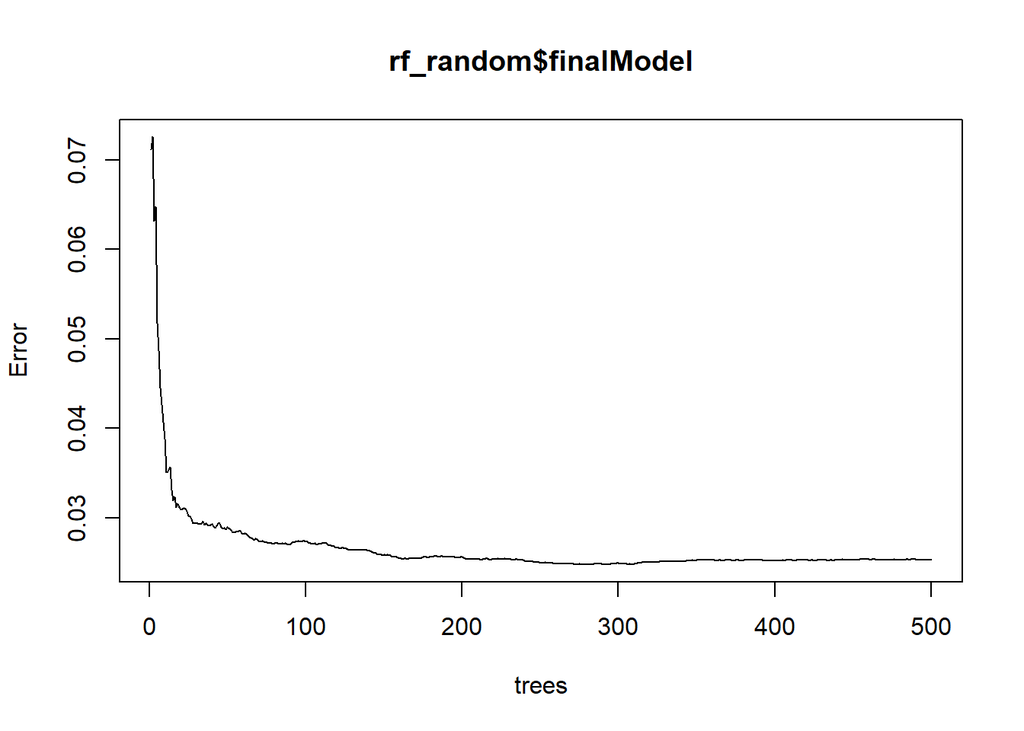

```r
plot(rf_random$finalModel)
```

This is a plot for mtry optimization carried out by the data processing.

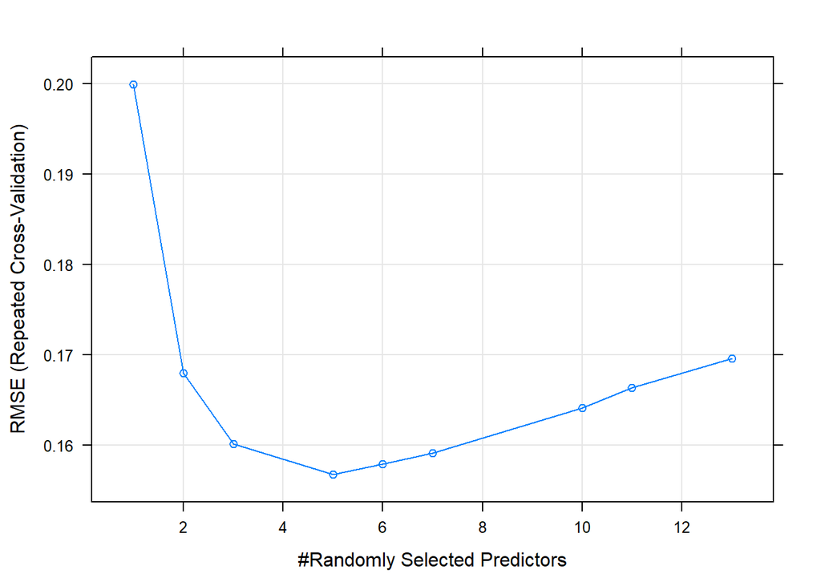

```r
plot(rf_random)
```

Now, we shall do the prediction using the inbuilt prediction function under the caret package.

```r
set.seed(1)
pred.m2=predict(rf_random, newdata=Bhousing.testing)
actuals_predicts= data.frame(cbind(actuals=Bhousing.testing$MEDV, predicts=exp(pred.m2)))

head(actuals_predicts)
```

```
##    actuals predicts
## 7     22.9 20.56414
## 15    18.2 19.76119
## 16    19.9 20.63592
## 18    17.5 18.13136
## 20    18.2 20.01658
## 21    13.6 14.44517
```

All the errors that one can have are:  
**RMSE**: Root Mean Squared Error  
**MPE**: Mean Percentage error  
**MAPE**: Mean Absolute Percentage Error  
**MSE**: Mean Squared Error  
**MAE**: Mean Absolute Error

```r
library(DMwR)
library(lattice)
library(grid)
set.seed(1)
r=regr.eval(actuals_predicts$actuals,actuals_predicts$predicts)
r
```

```
##        mae        mse       rmse       mape
##  2.2071137 11.1006504  3.3317639  0.1067818
```

The percentage of RMSE is:

```r
r_1=as.data.frame(r)
r_1[3,]/mean(Bhousing$MEDV)*100
```

```
## [1] 14.78628
```

Now we shall try to see how good is the prediction graphically.

We have a predefined function for this, available in my github repo, **anu-coder/R_utils**, I will be intalling the same to find out this plot. One can use the help function to find out the details of the function being used here after installing the package.

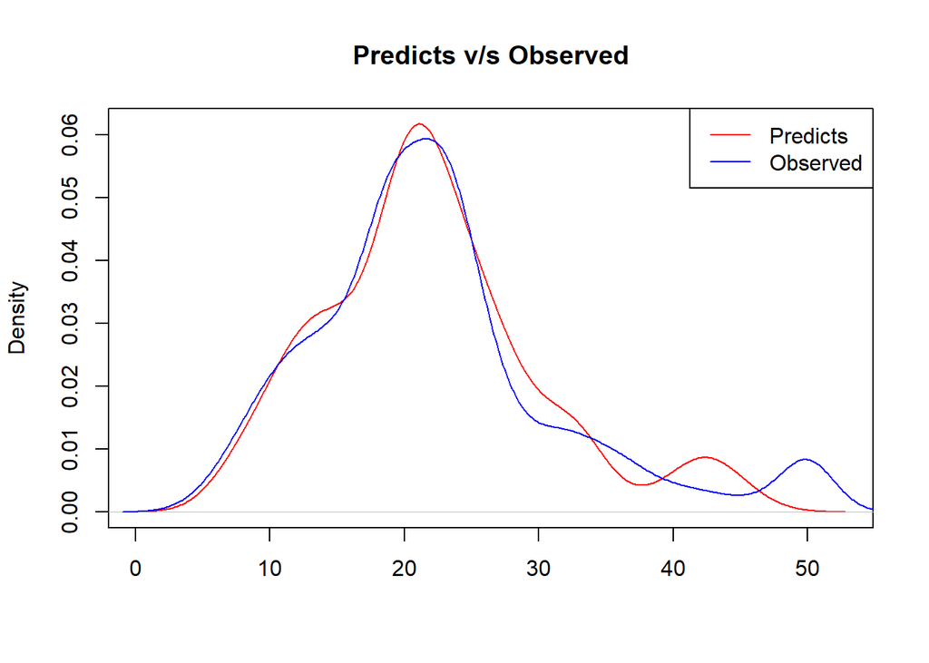

```r
library(devtools)
library(usethis)
devtools::install_github("anu-coder/R_utils")
library(testcase)
compare.dens(actuals_predicts$predicts, actuals_predicts$actuals, legend = c("Predicts","Observed"))
```

### GRID Search

Next we shall be using *grid search* technique and see if the model improves at all.

```r
library(caret)
library(randomForest)
control <- trainControl(method='cv',
                        number=10,
                        search = 'grid')

#Random generate 15 mtry values with tuneLength = 15

tuneGrid <- expand.grid(mtry=c(1:13))
set.seed(10)
rf_random_grid <- train(log(MEDV) ~ .,
                   data = Bhousing.training,
                   method = 'rf',
                   tuneGrid=tuneGrid,
                   trControl = control)
print(rf_random_grid)
```

```
## Random Forest
##
## 356 samples
##  13 predictor
##
## No pre-processing
## Resampling: Cross-Validated (10 fold)
## Summary of sample sizes: 320, 320, 319, 322, 321, 320, ...
## Resampling results across tuning parameters:
##
##   mtry  RMSE       Rsquared   MAE
##    1    0.2019006  0.7819544  0.1371407
##    2    0.1687876  0.8400771  0.1158036
##    3    0.1585581  0.8569638  0.1084000
##    4    0.1578514  0.8557826  0.1083019
##    5    0.1555766  0.8590033  0.1069030
##    6    0.1576106  0.8537098  0.1073569
##    7    0.1589289  0.8510687  0.1086962
##    8    0.1594498  0.8500984  0.1084108
##    9    0.1622041  0.8439345  0.1099225
##   10    0.1638005  0.8404527  0.1102975
##   11    0.1653521  0.8375645  0.1113660
##   12    0.1674605  0.8328703  0.1124153
##   13    0.1693752  0.8294648  0.1128614
##
## RMSE was used to select the optimal model using the smallest value.
## The final value used for the model was mtry = 5.
```

```r
set.seed(10)
pred.m2=predict(rf_random, newdata=Bhousing.testing)
actuals_predicts= data.frame(cbind(actuals=Bhousing.testing$MEDV, predicts=exp(pred.m2)))

head(actuals_predicts)
```

```
##    actuals predicts
## 7     22.9 20.56414
## 15    18.2 19.76119
## 16    19.9 20.63592
## 18    17.5 18.13136
## 20    18.2 20.01658
## 21    13.6 14.44517
```

```r
library(DMwR)
library(lattice)
library(grid)
set.seed(10)
r=regr.eval(actuals_predicts$actuals,actuals_predicts$predicts)
r
```

```
##        mae        mse       rmse       mape
##  2.2071137 11.1006504  3.3317639  0.1067818
```

We see that there isn’t much change in the RMSE value after doing a grid search, the mtry value is still 5. So we shall stick to **Random Forest** as our best model.